# 101-Klamath-estuary-GSI-rubias

Neil Thompson

Last Updated: 2020-05-14

```r
library(tidyverse)
library(rubias)

dir.create("outputs/101", recursive = TRUE, showWarnings = FALSE)
```

# 1. Load GSI baseline data frame.

Baseline final has samples with less than 15% missing data and there are no duplicates.

```r
baseline_final <- readRDS("./data/101-GSI-rubias-baseline-data.rds")
baseline_final %>%
  count(collection, repunit) %>%
  arrange(repunit)
```

| collection | repunit | n |
| --- | --- | --- |
| BlueFall | BlueCreek | 45 |
| EelVAfl | CoastalCA | 240 |
| RussianWSH | CoastalCA | 194 |
| TRHsibs | TrinityRiver | 55 |
| TrinityFall | TrinityRiver | 344 |
| TrinitySp | TrinityRiver | 263 |
| EastForkSouthForkSalmonRiver | UpperKlamath | 5 |
| IGH | UpperKlamath | 1229 |
| SalmonFall | UpperKlamath | 2 |
| SalmonR | UpperKlamath | 24 |

[output cut: 5 more lines]

Some of those collection counts are pretty dang small. I’m going to lump all Salmon River collections into a single collection. The rest of the collections look good to me.

```r
baseline_final <- baseline_final %>%
  mutate(collection = ifelse(collection %in% c("SouthForkSalmonRiver", "SalmonSp", "SalmonRiver", "SalmonR", "SalmonFall", "EastForkSouthForkSalmonRiver"), "SalmonRiver", collection))

baseline_final %>%
  count(collection, repunit) %>%
  arrange(repunit)
```

| collection | repunit | n |
| --- | --- | --- |
| BlueFall | BlueCreek | 45 |
| EelVAfl | CoastalCA | 240 |
| RussianWSH | CoastalCA | 194 |
| TRHsibs | TrinityRiver | 55 |
| TrinityFall | TrinityRiver | 344 |
| TrinitySp | TrinityRiver | 263 |
| IGH | UpperKlamath | 1229 |
| SalmonRiver | UpperKlamath | 234 |
| ScottFall | UpperKlamath | 86 |
| ShastaFall | UpperKlamath | 39 |

For this analysis the baseline data will have the following groups:

1. Trinity River (Trinity River hatchery spring and Trinity River hatchery fall)
2. Klamath River (Salmon River [includes Salmon River fall, Salmon River spring, Salmon River samples], Scott River fall, Shasta River fall), Iron Gate hatchery)
3. Blue River (this is part of the Southern Oregon and Northern California Coastal ESU even though it is a lower Klamath River tributary)
4. Coastal California (Russian and Eel rivers)

# 2. Load the mixture data frame of the klamath at-entry samples.

```r
mixture_final <- read_rds("./data/101-GSI-rubias-mixture-data.rds")
```

# 3. Self-assignment evaluation of the baseline

```r
sa_chinook <- self_assign(reference = baseline_final, gen_start_col = 5)
```

```
## Summary Statistics:
##
## 2729 Individuals in Sample
##
## 124 Loci: tag_id_1030_1, tag_id_1079_1, tag_id_1126_1, tag_id_1144_1, tag_id_115_1, tag_id_1191_1, tag_id_120_1, tag_id_1227_1, tag_id_1243_1, tag_id_1276_1, tag_id_1281_1, tag_id_1363_1, tag_id_1413_1, tag_id_1425_1, tag_id_1428_1, tag_id_1470_1, tag_id_1551_1, tag_id_1554_1, tag_id_1629_1, tag_…
##
## 4 Reporting Units: BlueCreek, CoastalCA, TrinityRiver, UpperKlamath
##
## 10 Collections: BlueFall, EelVAfl, RussianWSH, TRHsibs, TrinityFall, TrinitySp, SalmonRiver, IGH, ScottFall, ShastaFall
##
## 1.80% of allelic data identified as missing
```

```r
sa_to_repu <- sa_chinook %>%
  group_by(indiv, collection, repunit, inferred_repunit) %>%
  summarise(repu_scaled_like = sum(scaled_likelihood))

sa_to_repu %>%
  group_by(indiv) %>%
  top_n(1, wt = repu_scaled_like) %>%
  mutate(same_pop = ifelse(repunit == inferred_repunit, "yes", "no")) %>%
  ungroup() %>%
  count(same_pop)
```

| same_pop | n |
| --- | --- |
| no | 100 |
| yes | 2629 |

The baseline has a 96.3 correct assignment percentage to original reporting unit.

Which baseline samples are assigned to an “incorrect” population?

```r
sa_to_repu %>%
  group_by(indiv) %>%
  top_n(1, wt = repu_scaled_like) %>%
  mutate(same_pop = ifelse(repunit == inferred_repunit, "yes", "no")) %>%
  ungroup() %>%
  filter(same_pop == "no") %>%
  mutate(tmp = paste0(repunit, "_", inferred_repunit)) %>%
  count(tmp) %>%
  separate(tmp, into = c("repunit", "inferred_repunit"))
```

| repunit | inferred_repunit | n |
| --- | --- | --- |
| BlueCreek | UpperKlamath | 4 |
| TrinityRiver | BlueCreek | 1 |
| TrinityRiver | UpperKlamath | 37 |
| UpperKlamath | BlueCreek | 7 |
| UpperKlamath | CoastalCA | 1 |
| UpperKlamath | TrinityRiver | 50 |

Calculate repunit self-assignment accuracy

```r
sa_to_repu %>%
  group_by(indiv) %>%
  top_n(1, wt = repu_scaled_like) %>%
  mutate(same_pop = ifelse(repunit == inferred_repunit, "yes", "no")) %>%
  ungroup() %>%
  group_by(repunit) %>%
  count(same_pop) %>%
  mutate(tot_fish = sum(n)) %>%
  filter(same_pop == "yes") %>%
  mutate(assign_rate = n / tot_fish) %>%
  rename(n_same = n)
```

| repunit | same_pop | n_same | tot_fish | assign_rate |
| --- | --- | --- | --- | --- |
| BlueCreek | yes | 41 | 45 | 0.9111111 |
| CoastalCA | yes | 434 | 434 | 1.0000000 |
| TrinityRiver | yes | 624 | 662 | 0.9425982 |
| UpperKlamath | yes | 1530 | 1588 | 0.9634761 |

4. Perform a mixture analysis using the boostrap correction reporting unit proportions RUBIAS settings from https://github.com/eriqande/rubias/blob/master/vignettes/rubias-overview.Rmd

```r
mix_est_pb <- infer_mixture(
  reference = baseline_final,
  mixture = mixture_final,
  gen_start_col = 5,
  method = "PB"
)
```

Reporting mixture proportion estimates for each baseline population

```r
rep_mix_ests <- mix_est_pb$mixing_proportions %>%
  group_by(mixture_collection, repunit) %>%
  summarise(repprop = round(sum(pi), 3))

rep_mix_ests %>%
  arrange(desc(repprop))
```

| mixture_collection | repunit | repprop |
| --- | --- | --- |
| KlamathEntry | TrinityRiver | 0.475 |
| KlamathEntry | UpperKlamath | 0.434 |
| KlamathEntry | BlueCreek | 0.088 |
| KlamathEntry | CoastalCA | 0.003 |

Calculate individuals posteriors

```r
rep_indiv_ests <- mix_est_pb$indiv_posteriors %>%
  group_by(mixture_collection, indiv, repunit) %>%
  summarise(rep_pofz = sum(PofZ))

rep_indiv_ests %>%
  group_by(indiv) %>%
  arrange(desc(rep_pofz)) %>%
  slice(1) %>%
  ungroup()
```

| mixture_collection | indiv | repunit | rep_pofz |
| --- | --- | --- | --- |
| KlamathEntry | chinook11118 | TrinityRiver | 0.9988123 |
| KlamathEntry | chinook11119 | TrinityRiver | 0.9812437 |
| KlamathEntry | chinook11121 | TrinityRiver | 0.8759555 |
| KlamathEntry | chinook11122 | TrinityRiver | 0.7621682 |
| KlamathEntry | chinook11123 | TrinityRiver | 0.7140372 |
| KlamathEntry | chinook11124 | TrinityRiver | 0.9874013 |
| KlamathEntry | chinook11125 | TrinityRiver | 0.9988709 |
| KlamathEntry | chinook11126 | TrinityRiver | 0.9999978 |
| KlamathEntry | chinook11127 | TrinityRiver | 0.9051949 |
| KlamathEntry | chinook11130 | TrinityRiver | 0.9991273 |

[output cut: 498 more lines]

# plot the mixture estimates from each group.

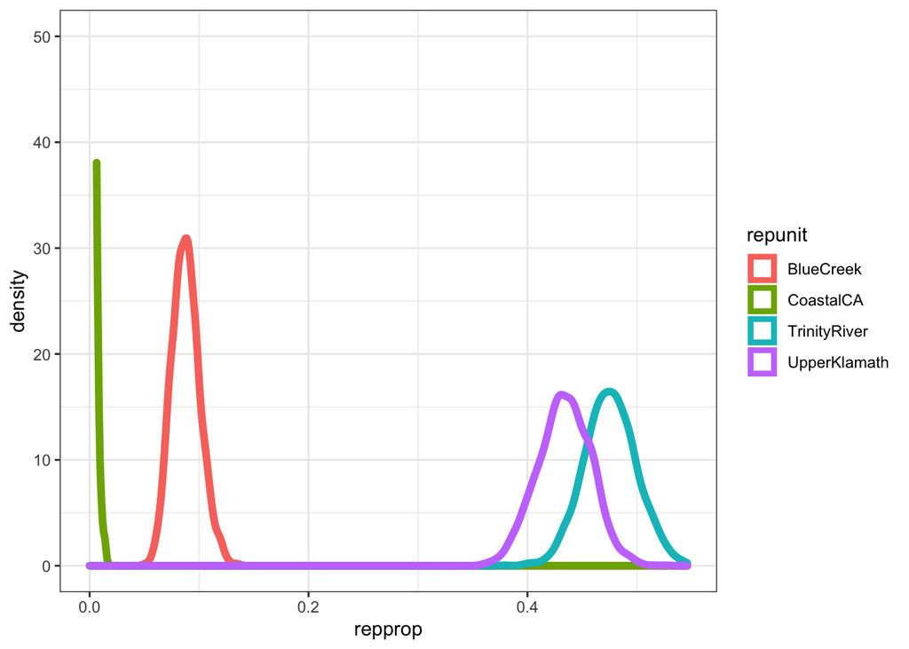

```r
nsweeps <- max(mix_est_pb$mix_prop_traces$sweep)

trace_subset <- mix_est_pb$mix_prop_traces %>%
  filter(sweep > 200) %>%
  group_by(sweep, repunit) %>%
  summarise(repprop = sum(pi))

ggplot(trace_subset, aes(x = repprop, colour = repunit)) +
  geom_density(size = 2) +
  ylim(0, 50) +
  theme_bw()
```

Lets see if any of the fish look like non Klamath River basin fish, blue line should mirror the black line.

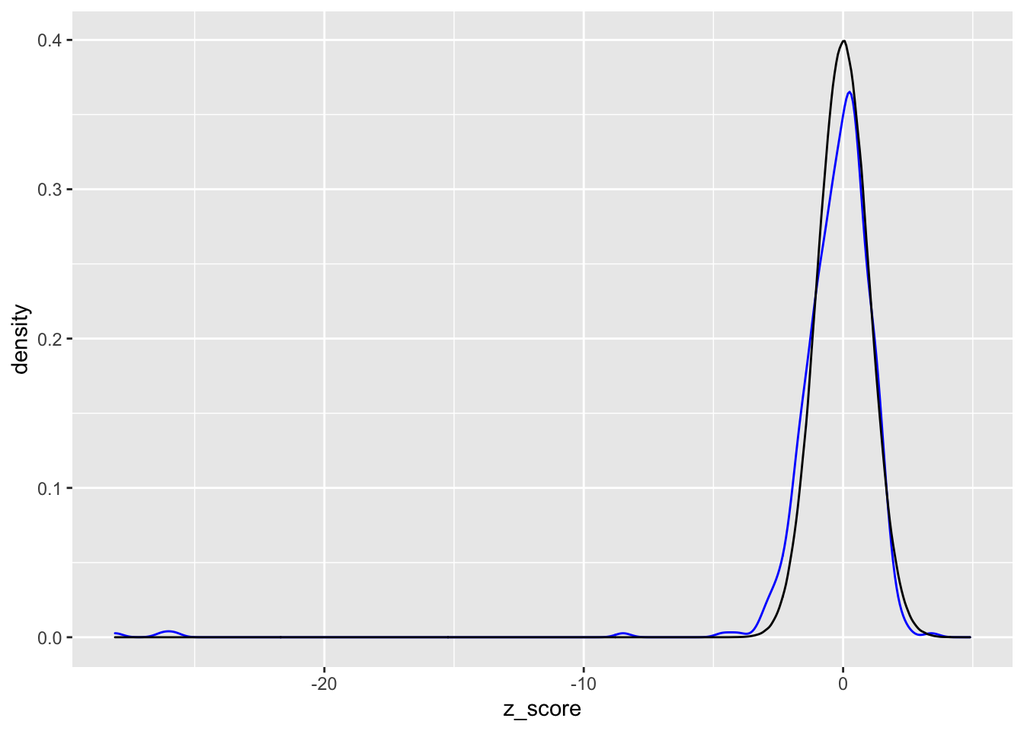

```r
# get the maximum-a-posteriori population for each individual
map_rows <- mix_est_pb$indiv_posteriors %>%
  group_by(indiv) %>%
  top_n(1, PofZ) %>%
  ungroup()

normo <- tibble(z_score = rnorm(1e06))

ggplot(map_rows, aes(x = z_score)) +
  geom_density(colour = "blue") +
  geom_density(data = normo, colour = "black")
```

Computing credible intervals

```r
top_cis <- trace_subset %>%
  group_by(repunit) %>%
  summarise(
    pt_est = round(mean(repprop), 3),
    loCI = round(quantile(repprop, probs = 0.025), 3),
    hiCI = round(quantile(repprop, probs = 0.975), 3)
  )
top_cis
```

| repunit | pt_est | loCI | hiCI |
| --- | --- | --- | --- |
| BlueCreek | 0.088 | 0.065 | 0.116 |
| CoastalCA | 0.003 | 0.000 | 0.009 |
| TrinityRiver | 0.476 | 0.430 | 0.523 |
| UpperKlamath | 0.434 | 0.386 | 0.480 |

There is 1 fish that didn’t assign to a Klamath Basin reporting unit. Let’s see what RoSA genotype that fish has.

```r
kl_rosa <- read_rds("./data/101-RoSA-klamath-estuary-samples.rds")
kl_rosa %>% filter(Indiv == "CH11459")
```

| NMFS_DNA_ID | Indiv | Population | rosa |
| --- | --- | --- | --- |
| T153835 | CH11459 | KlamathEntry | LLLLLLLL |

Having a homozygous late genotype in a fish assigned to the CoastalCA repunit isn’t surprising. It makes sense that the fish is homozygous late as only fall-run ecotype fish are present in the CoastalCA repunit.

Write an RDS to use in later analyses.

```r
dir.create("./outputs")

estuary_assignments <- rep_indiv_ests %>%
  group_by(indiv) %>%
  arrange(desc(rep_pofz)) %>%
  slice(1) %>%
  ungroup()

write_rds(estuary_assignments, "./outputs/101/RoSA-klamath-estuary-rubias-assignments.rds", compress = "xz")
```

# Running Time

Running the code and rendering this notebook required approximately this much time on a Mac laptop of middling speed:

```r
Sys.time() - start_time
```

```
## Time difference of 20.07908 secs
```